# RegressionMLE_HW_Elting: Using Maximum Likelihood to Solve Regression Parameters

Rosalee Elting

2023-01-30

# 1 Michaelis-Menten Non-Linear regression

Here we will be using the non-linear Michaelis-Menten regression to complete our model.
$$U = \frac
{U{max}S}{K{s}+S}$$

# 2 Our Known Parameters

$U{max}$ =1  
$K{s}$ = 50  
$\sigma$ = 0.05  
$n$=20

# 3 Creating the Model

## 3.1 Generating fake data

Generate fake data , assuming normally distributed errors *here I am generating fake data, that is normally distribute to represent my x and y values* First I’m inputting my known values from above into R

```r
umax <- 1
ks <- 50
sig <- 0.05
```

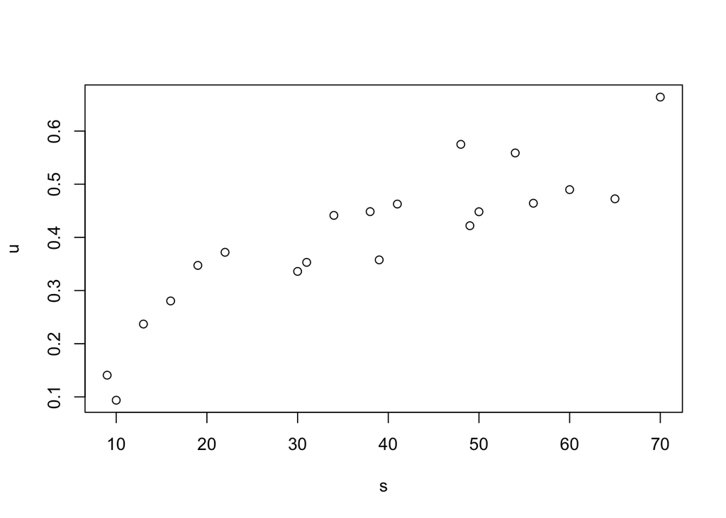

```r
# I want my variable S in the Michaelis-Menten formula to go from 5 to 100.
set.seed(40)
#making a range of values that s could be pulled from.
range <- seq(from=5, to =100, by =1)
#taking a subset of x values for s,
s <- sample(x= range, size =20)
#making a random variable, e, to represent error points of this normal distributed data set.
e <- rnorm(n=20, mean=0, sd =0.05)
#now inputting the M-M formula to produce u values from these s values
u <- (umax*s/(ks+s))+e
#Plotting my fake data that follows a M-M curve.
plot(s,u)
```

# 4 Creating a function to report likelihood

I will now create a function to report the likelihood of the parameters, given the data I created in the above chunk using M-M formula and randomly distributed samples. *I do this first by creating a function*

```r
mmlike <- function(P, u, s) {
  uhat <- P[1]*s /(P[2]+s)
  like <- -sum(dnorm(x=u, mean = uhat, sd = exp(P[3]), log =T))
  return(like)
}
#P[1] equals Umax, P[2] equals Ks and P[3] equals the given sigma standard deviation
```

# 5 Searching for the best parameters

Here I use the nlm (non linear minimization) function to estimate the best value of my parameters that will minimize the negative log likelihood of several parameters at one time. I use the mmlike function I made in the previous chunk as the function_to_minimize, one of the arguments in the nlm function.

```r
mmout <- nlm(mmlike, p= c(1,2,3), u, s)
mmout
```

```
## $minimum
## [1] -29.06576
##
## $estimate
## [1]  0.8646424 38.6109660 -2.8722265
##
## $gradient
## [1] -3.831513e-06  4.018349e-08 -1.200740e-07
##
## $code
## [1] 1
##
## $iterations
## [1] 20
```

```r
#P[3] is still in log format, so it must be exponentiation:
print(exp(-2.8722265))
```

```
## [1] 0.05657283
```

**This returns the following parameter estimates:**  
$U{max}$ = 0.8646424  
$K{s}$ = 38.6109660  
$\sigma$ = 0.05657283

# 6 Plot model fit on the data

Now plotting how our model fits the data I generated early in this assignment.

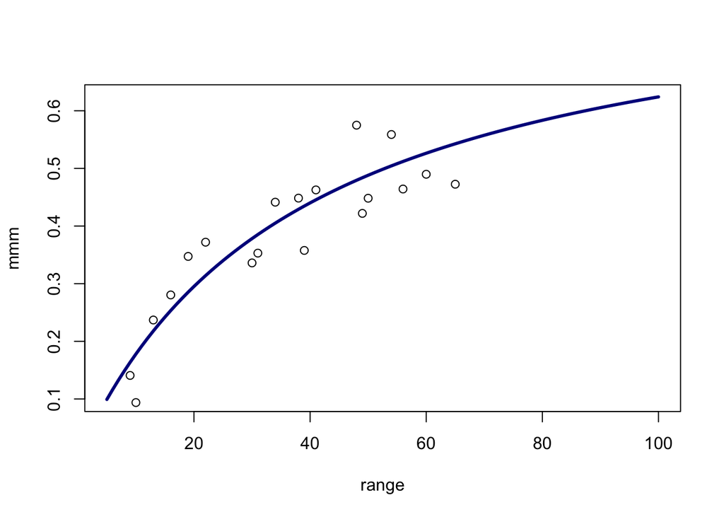

```r
#making a line for my Michaelis-Menten model
mmm <- 0.865*range/(38.61+range)
plot(range, mmm, type ='l', lwd = 3, col = "darkblue")
points(s,u)
```